# ggplot2 介绍

参考资料：https://github.com/thomasp85/ggplot2_workshop

### Dependencies

This document comes with a list of required packages.

# ggplot2 基本语法

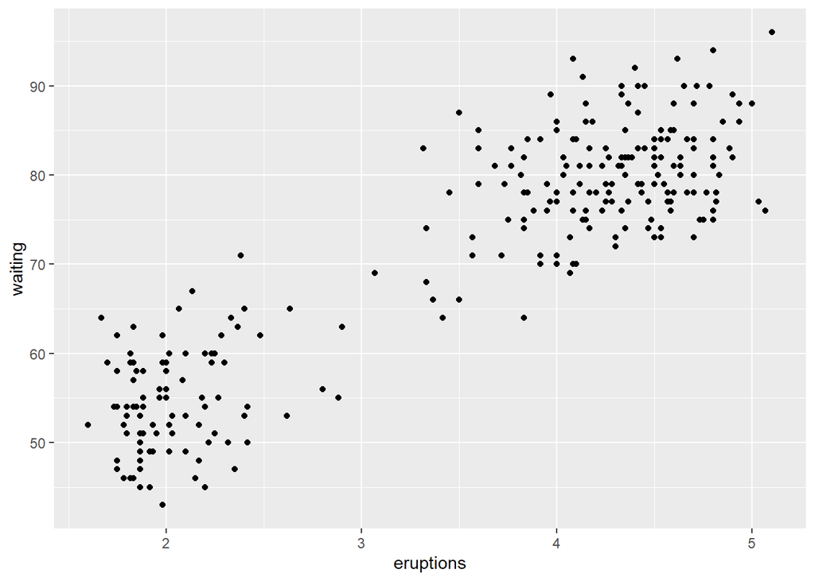

```r
data("faithful")
# 基础散点图
ggplot(data = faithful,
       mapping = aes(x = eruptions, y = waiting)) +
  geom_point()
```

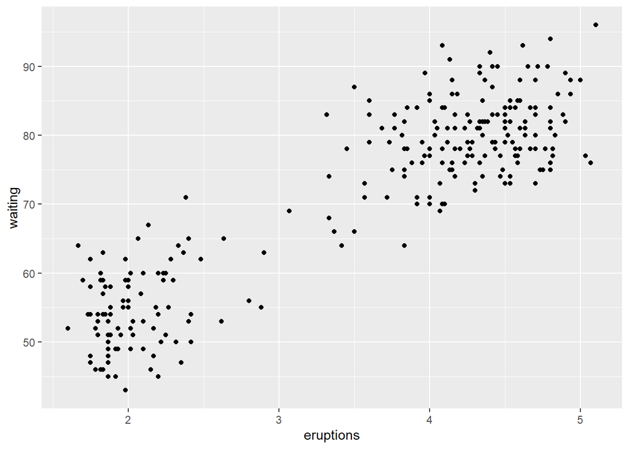

```r
# mapping可以全局放在ggplot里，也可以在图层中定义
ggplot() +
  geom_point(mapping = aes(x = eruptions, y = waiting),
             data = faithful)
```

数据的映射通过`aes()`

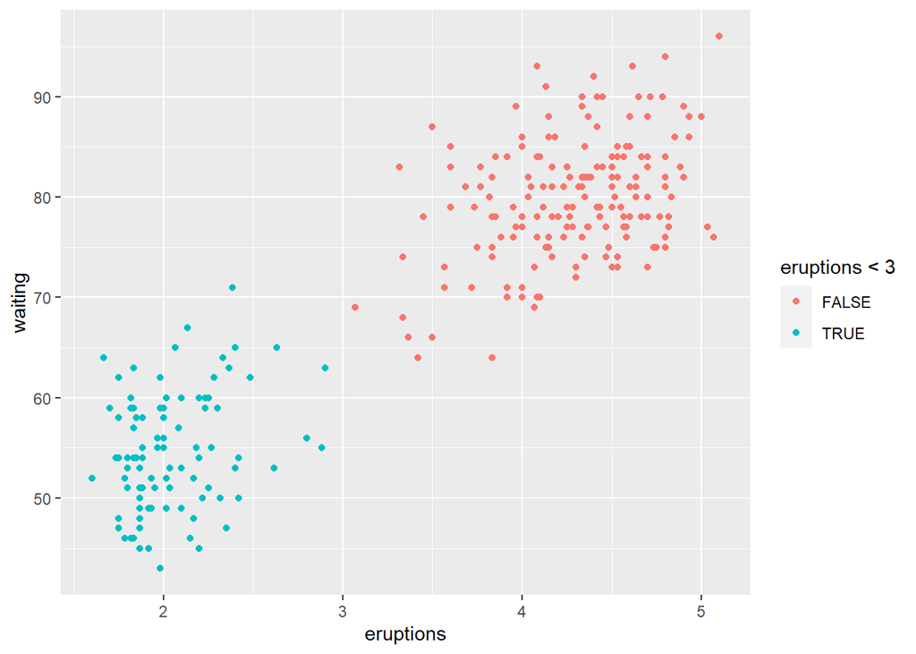

```r
ggplot(faithful) +
  geom_point(aes(x = eruptions, y = waiting, colour = eruptions < 3))
```

如果映射的对象不是一个变量，而是也一个固定值，将其放在 `aes()` 外部。

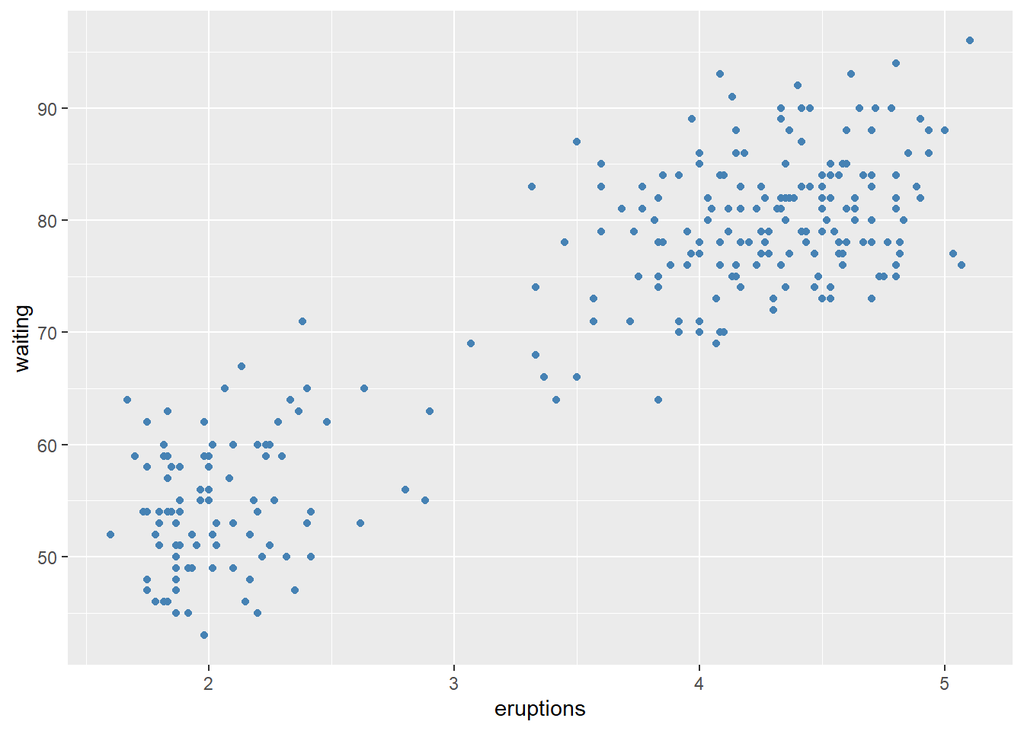

```r
ggplot(faithful) +
  geom_point(aes(x = eruptions, y = waiting),
             colour = 'steelblue')
```

某些geom对象只需要一个数据映射

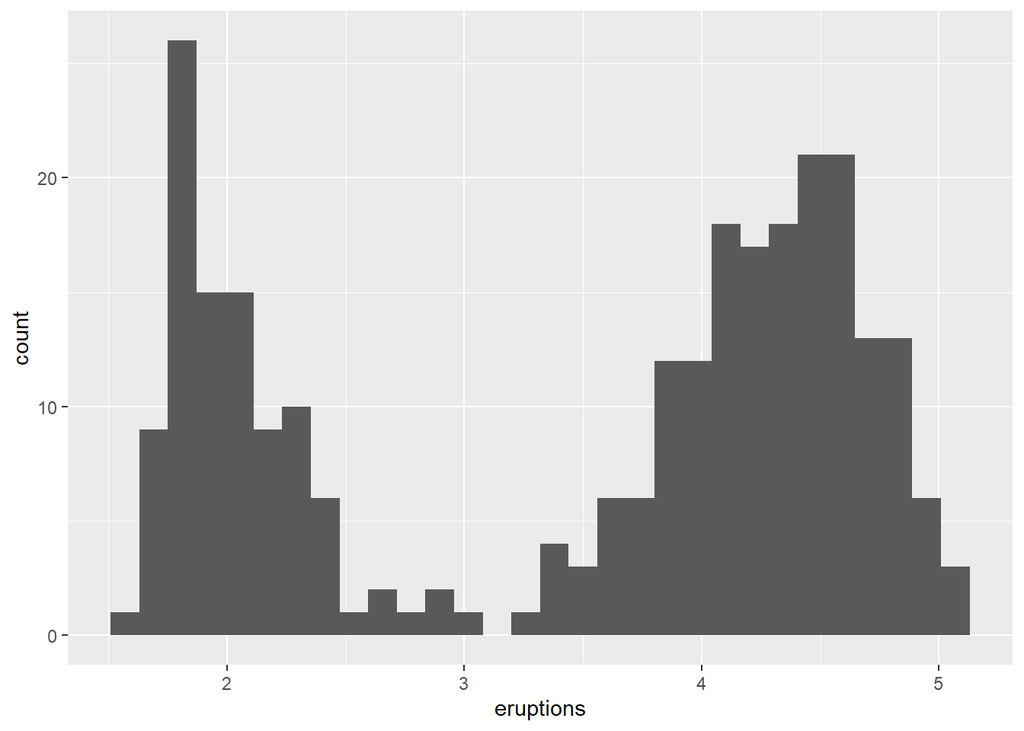

```r
ggplot(faithful) +
  geom_histogram(aes(x = eruptions))
```

geoms 即图层。图层的添加是由顺序的，类似于真实的绘图，后加入的图层会在前面的图层上进行绘制。

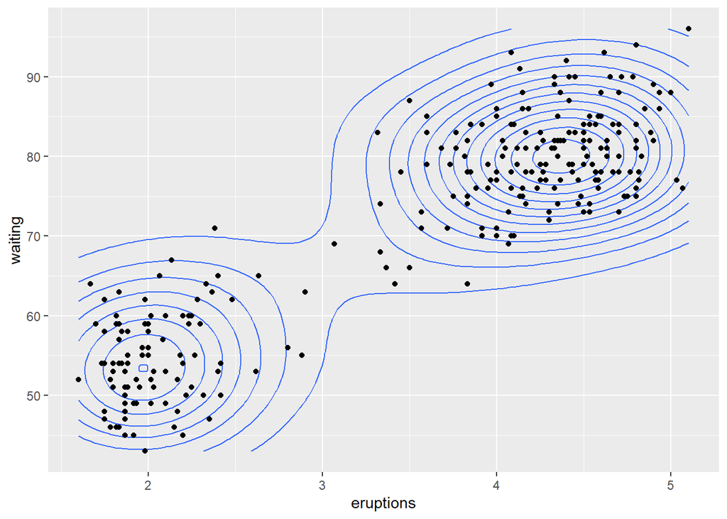

```r
ggplot(faithful, aes(x = eruptions, y = waiting)) +
  geom_density_2d() +
  geom_point()
```

### Stat

每个图层geom都有一个stat.下面绘制bar图时，count就是一个stat。

```r
data("mpg")
ggplot(mpg) +
  geom_bar(aes(x = class))
```

[output not shown]

stat是可以被覆盖改写的。如果我们实现计算好了count类的信息，可以使用`identity`指定不计算stat.

```r
library(dplyr)
```

```r
mpg_counted <- mpg %>%
  count(class, name = 'count')
ggplot(mpg_counted) +
  geom_bar(aes(x = class, y = count), stat = 'identity')
```

[output not shown]

也可以使用 `geom_col()`，它默认使用`stat_identity`。

```r
ggplot(mpg_counted) +
  geom_col(aes(x = class, y = count))
```

[output not shown]

在`aes()`中可以使用`after_stat()`获取计算的stat：

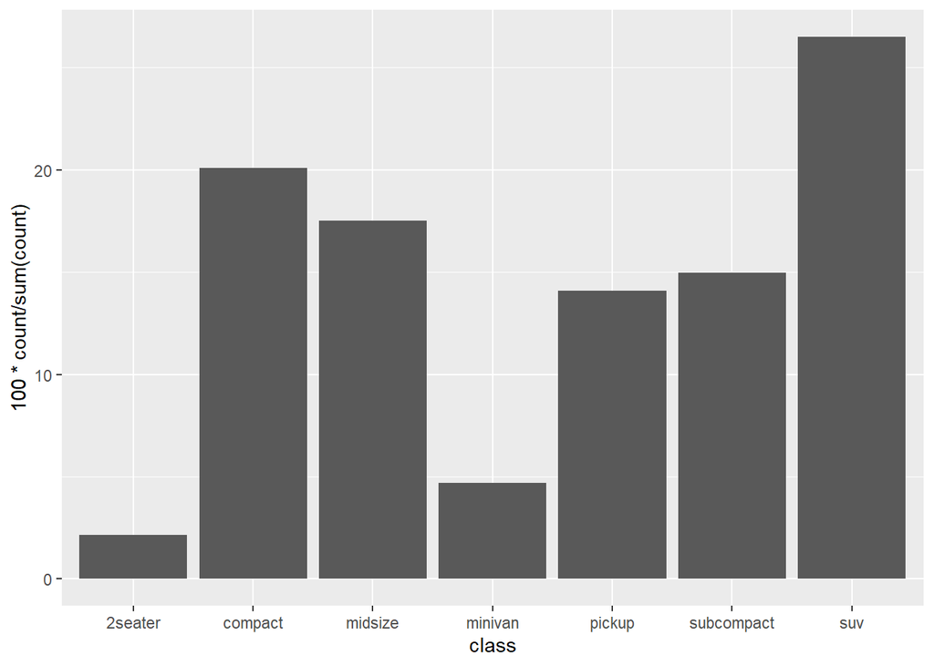

```r
ggplot(mpg) +
  geom_bar(aes(x = class, y = after_stat(100 * count / sum(count))))
```

某些geom会计算多个stat，但默认输出一个 (比如, `density`)

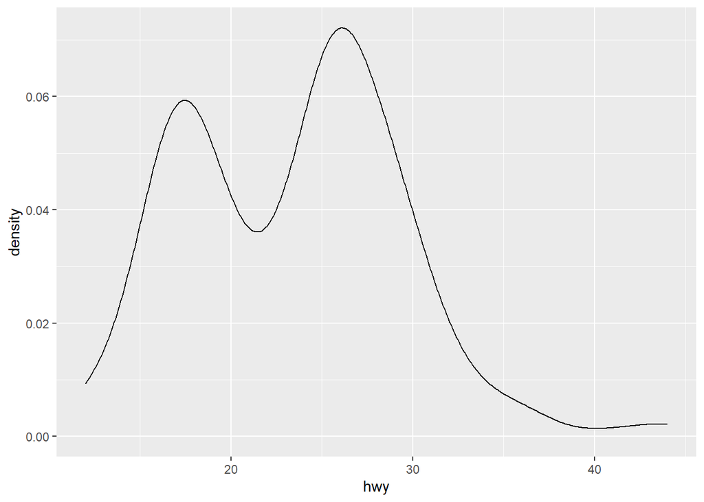

```r
ggplot(mpg) +
  geom_density(aes(x = hwy))
```

如果想使用非默认的stata，就需要 `after_stat()` 函数。

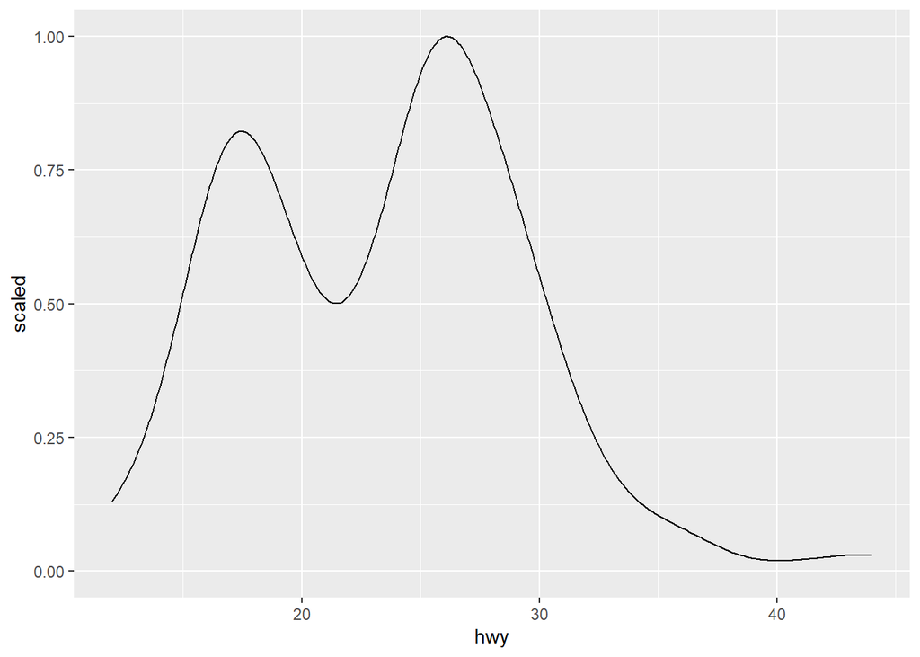

```r
ggplot(mpg) +
  geom_density(aes(x = hwy, y = after_stat(scaled)))
```

### Scales

scale定义了映射的方式：

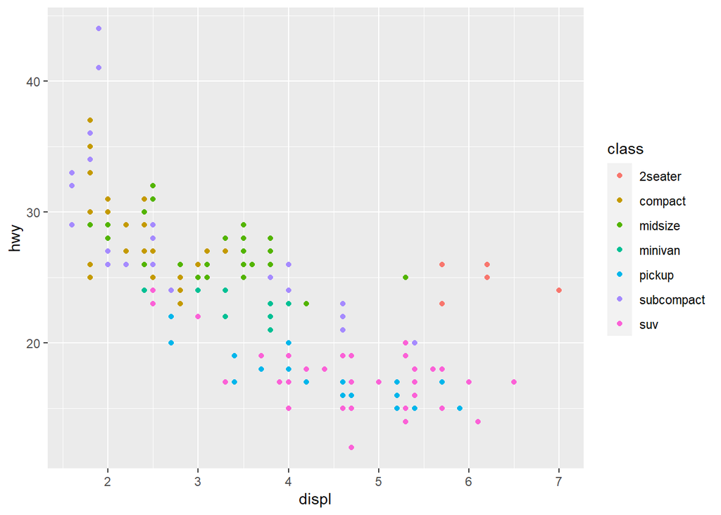

```r
ggplot(mpg) +
  geom_point(aes(x = displ, y = hwy, colour = class))
```

控制颜色：

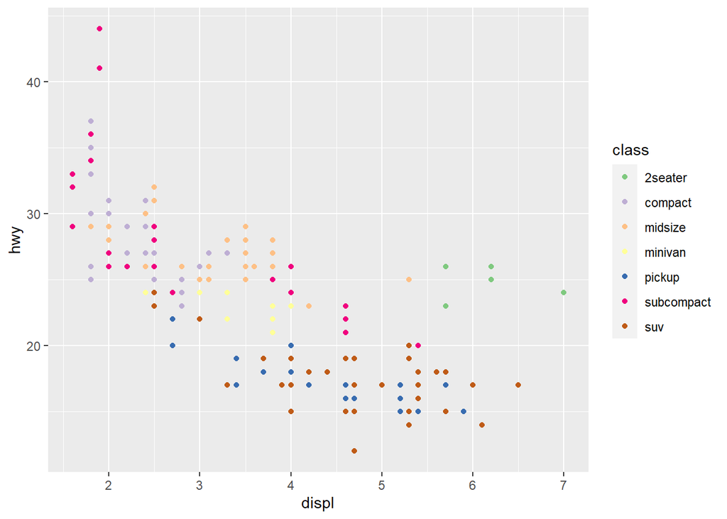

```r
ggplot(mpg) +
  geom_point(aes(x = displ, y = hwy, colour = class)) +
  scale_colour_brewer(type = 'qual')
```

控制位置：

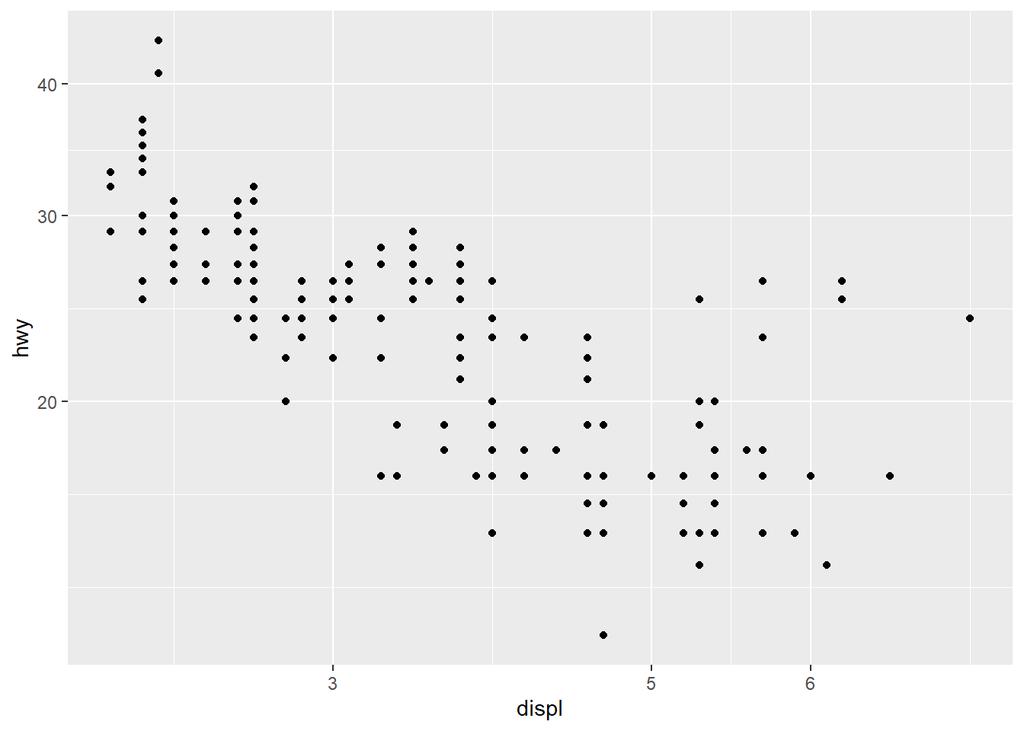

```r
ggplot(mpg) +
  geom_point(aes(x = displ, y = hwy)) +
  scale_x_continuous(breaks = c(3, 5, 6)) +
  scale_y_continuous(trans = 'log10')
```

### Facets 面板

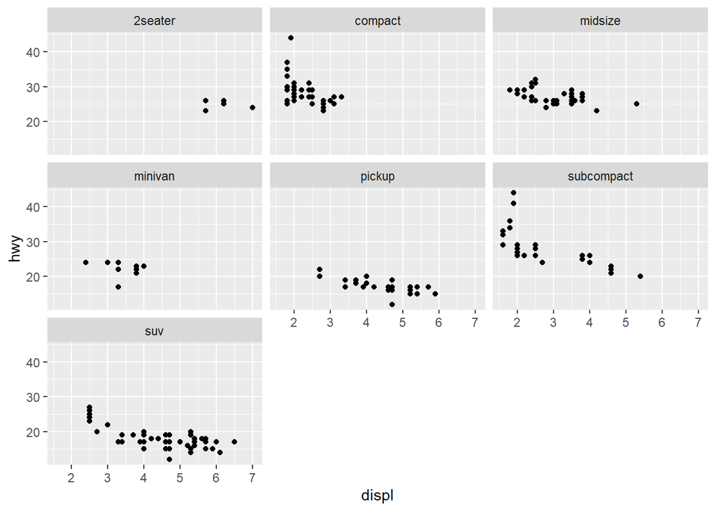

```r
ggplot(mpg) +
  geom_point(aes(x = displ, y = hwy)) +
  facet_wrap(~ class)
```

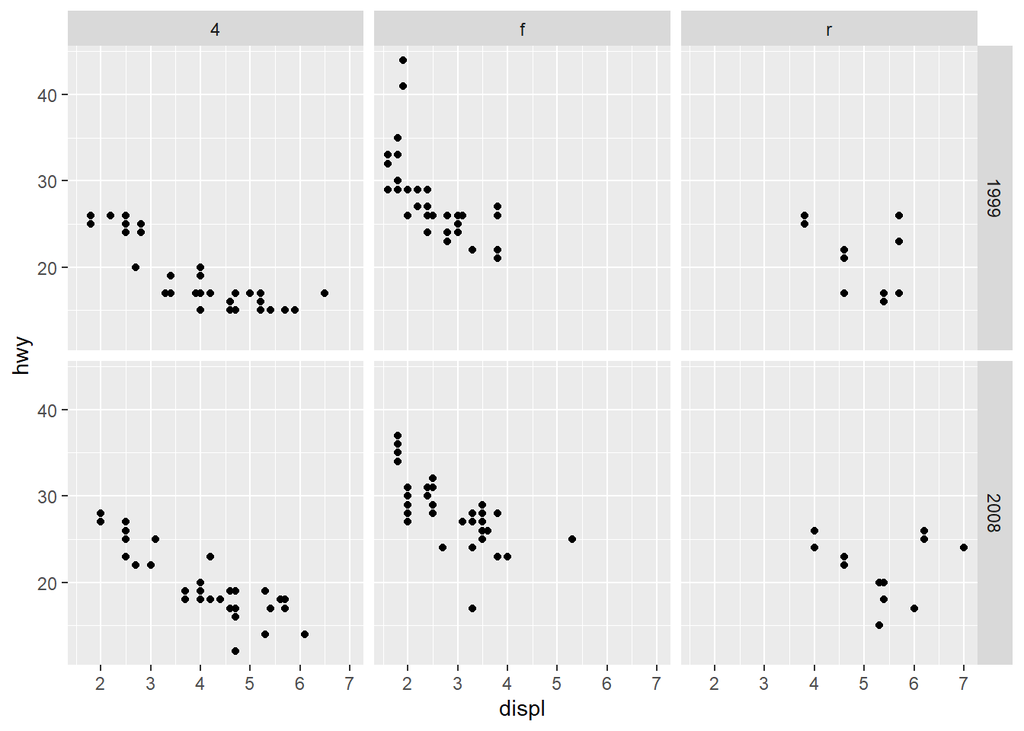

```r
ggplot(mpg) +
  geom_point(aes(x = displ, y = hwy)) +
  facet_grid(year ~ drv)
```

### Coordinates 坐标

默认为笛卡尔坐标系。改变坐标可能完全改变图样

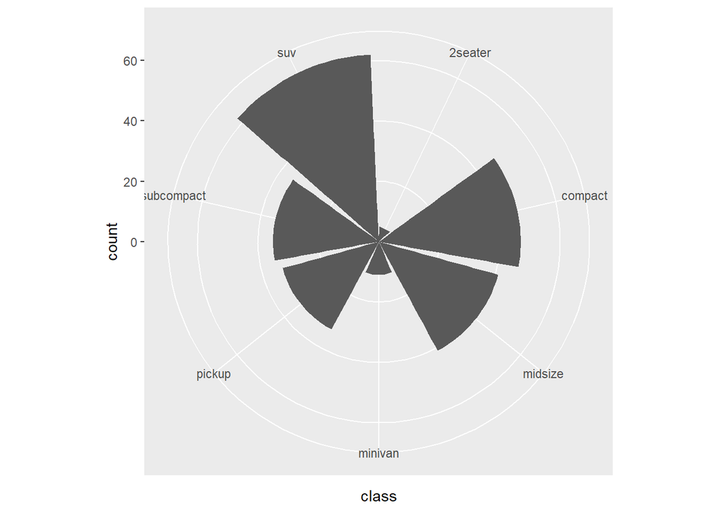

```r
ggplot(mpg) +
  geom_bar(aes(x = class)) +
  coord_polar()
```

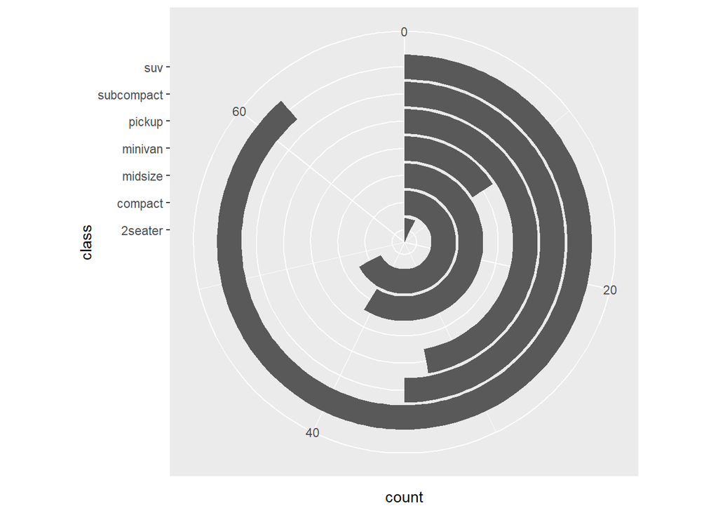

```r
ggplot(mpg) +
  geom_bar(aes(x = class)) +
  coord_polar(theta = 'y') +
  expand_limits(y = 70)
```

scale可以实现放大操作, 但最好与coord一起使用。

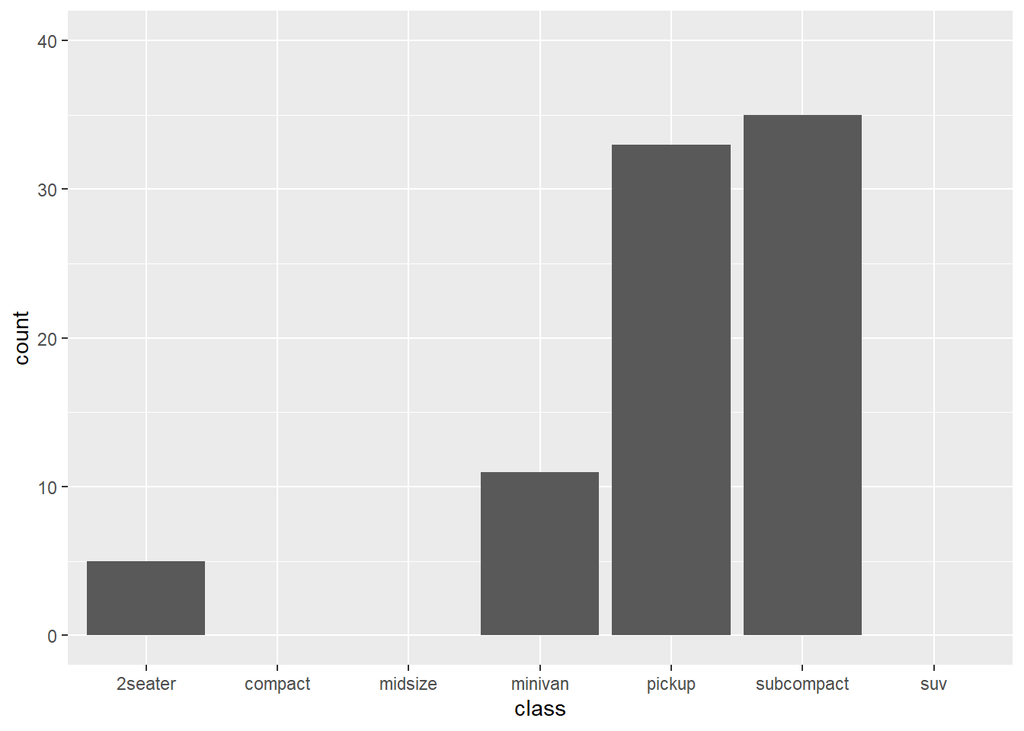

```r
ggplot(mpg) +
  geom_bar(aes(x = class)) +
  scale_y_continuous(limits = c(0, 40))
```

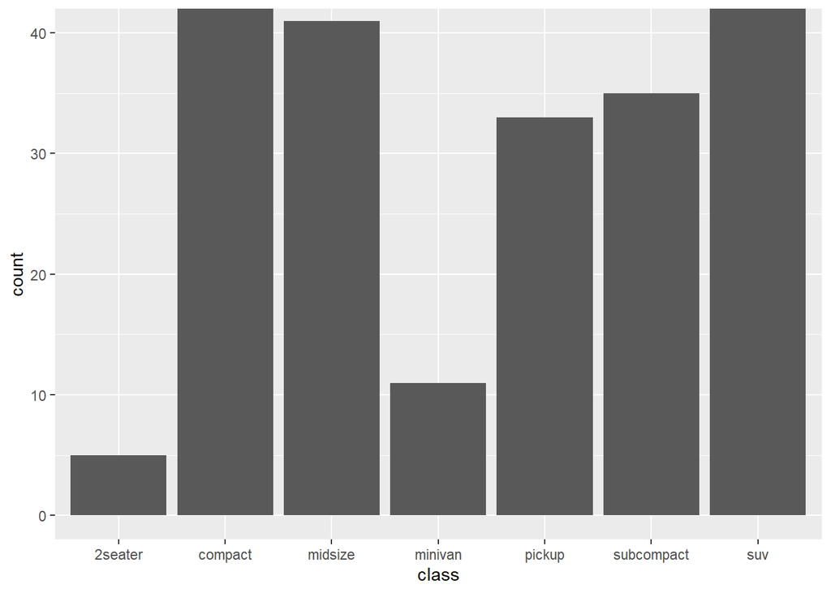

```r
ggplot(mpg) +
  geom_bar(aes(x = class)) +
  coord_cartesian(ylim = c(0, 40))
```

### Theme

主题是预先设置好的外观和样式的集合。

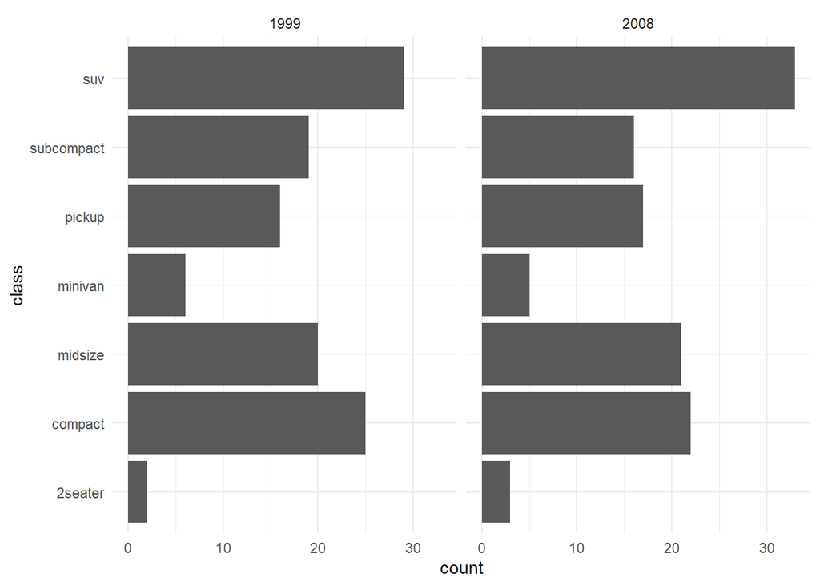

```r
ggplot(mpg) +
  geom_bar(aes(y = class)) +
  facet_wrap(~year) +
  theme_minimal()
```

也可以通过theme() 对每个细节进行重新设定。

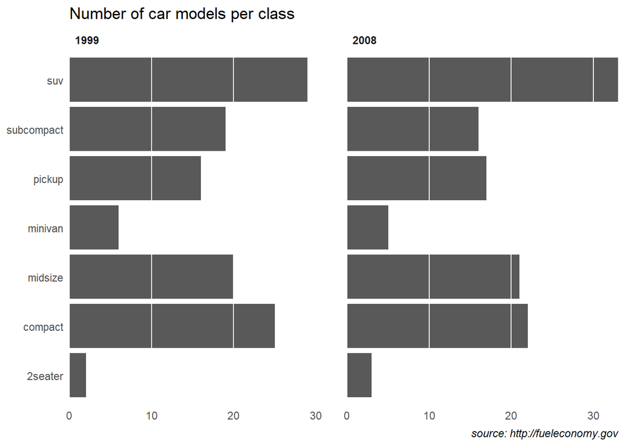

```r
ggplot(mpg) +
  geom_bar(aes(y = class)) +
  facet_wrap(~year) +
  labs(title = "Number of car models per class",
       caption = "source: http://fueleconomy.gov",
       x = NULL,
       y = NULL) +
  scale_x_continuous(expand = c(0, NA)) +
  theme_minimal() +
  theme(
    text = element_text('Avenir Next Condensed'),
    strip.text = element_text(face = 'bold', hjust = 0),
    plot.caption = element_text(face = 'italic'),
    panel.grid.major = element_line('white', size = 0.5),
    panel.grid.minor = element_blank(),
    panel.grid.major.y = element_blank(),
    panel.ontop = TRUE
  )
```

## 扩展

社区中包含各种ggplot2的扩展已实现一些复杂功能。

### 多图组合

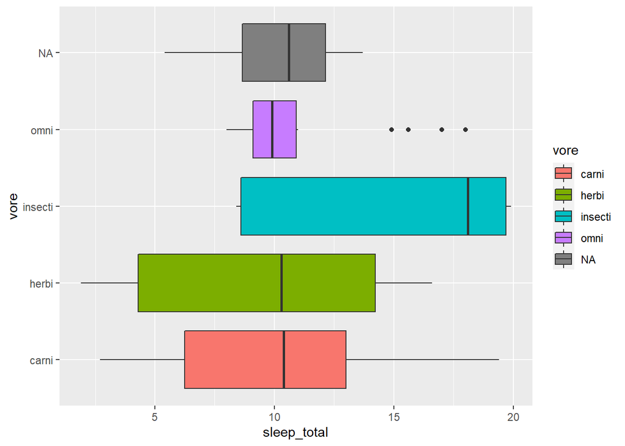

```r
p1 <- ggplot(msleep) +
  geom_boxplot(aes(x = sleep_total, y = vore, fill = vore))
p1
```

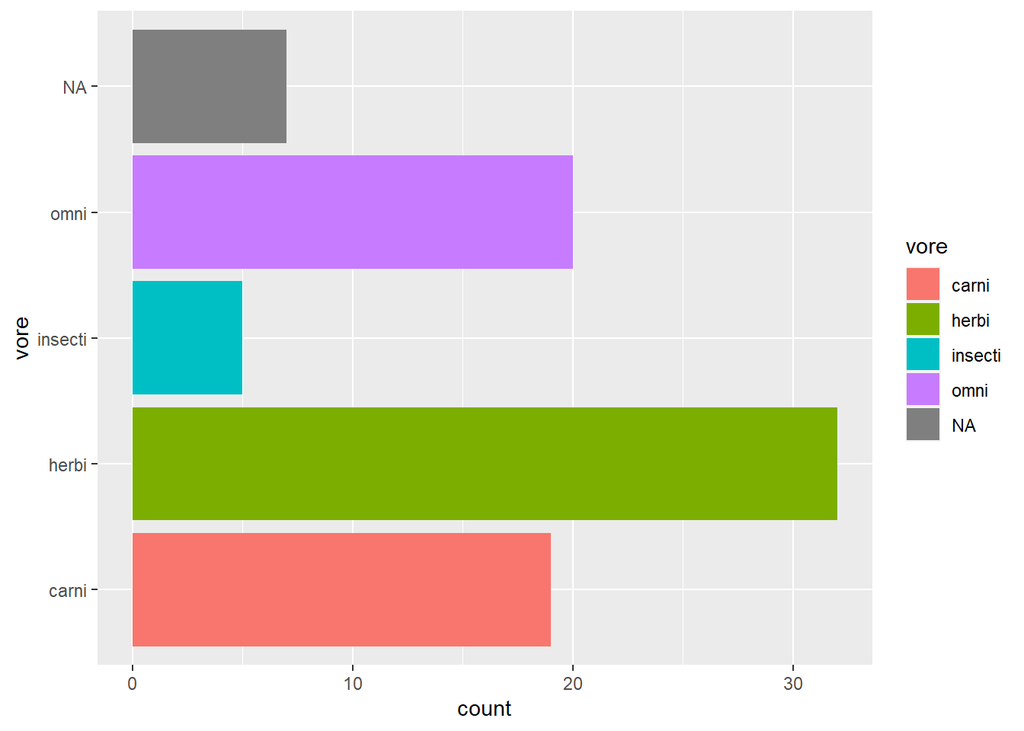

```r
p2 <- ggplot(msleep) +
  geom_bar(aes(y = vore, fill = vore))
p2
```

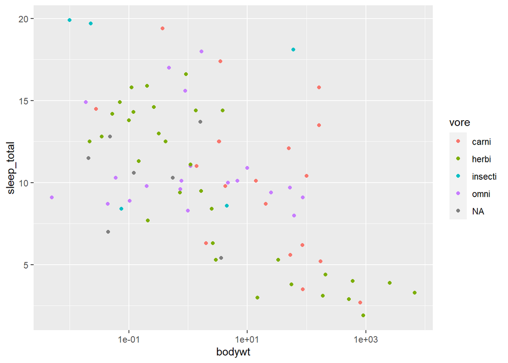

```r
p3 <- ggplot(msleep) +
  geom_point(aes(x = bodywt, y = sleep_total, colour = vore)) +
  scale_x_log10()
p3
```

使用 patchwork 组合图

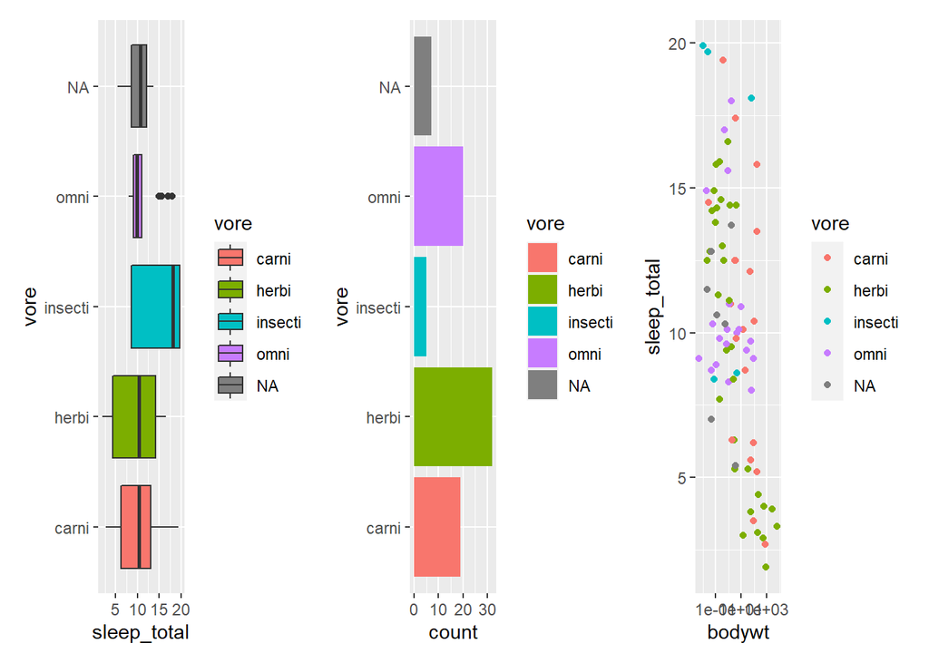

```r
library(patchwork)
p1 + p2 + p3
```

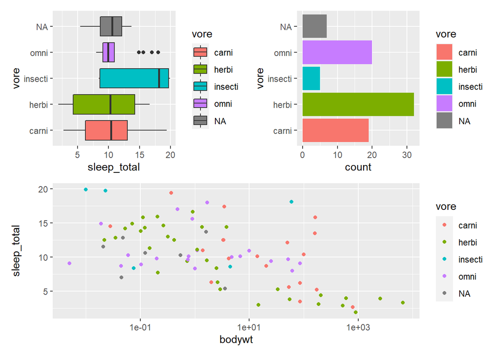

```r
(p1 | p2) /
   p3
```

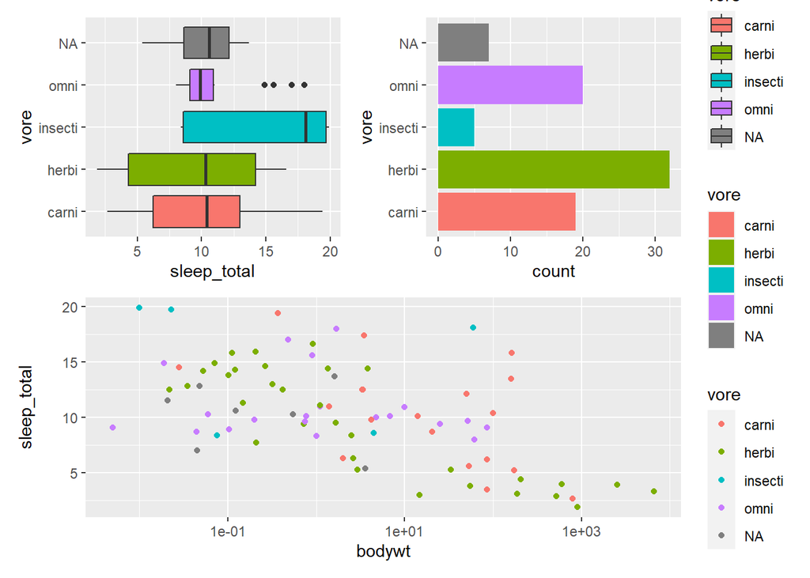

```r
p_all <- (p1 | p2) /
            p3
p_all + plot_layout(guides = 'collect')
```

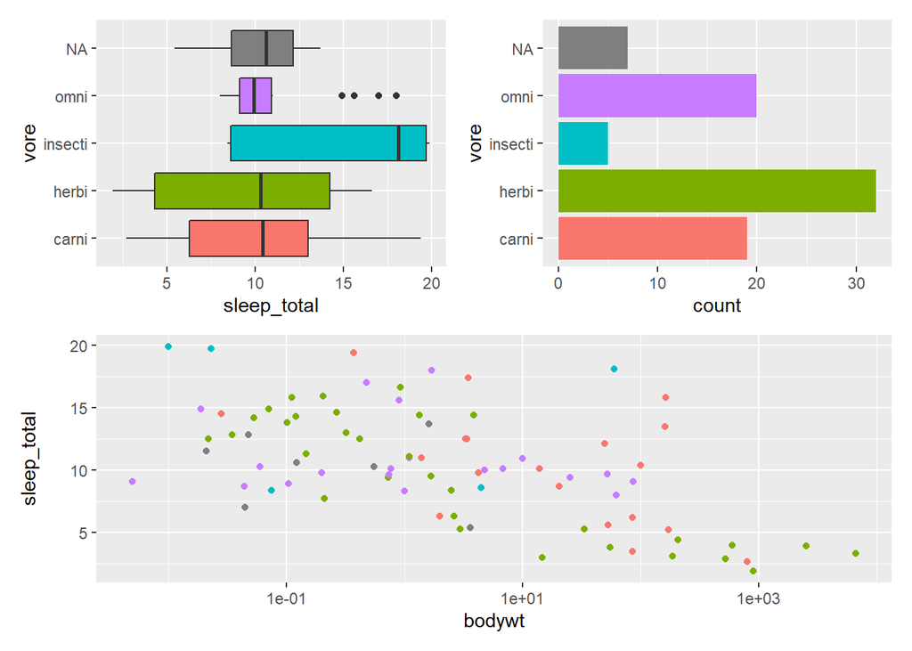

```r
p_all & theme(legend.position = 'none')
```

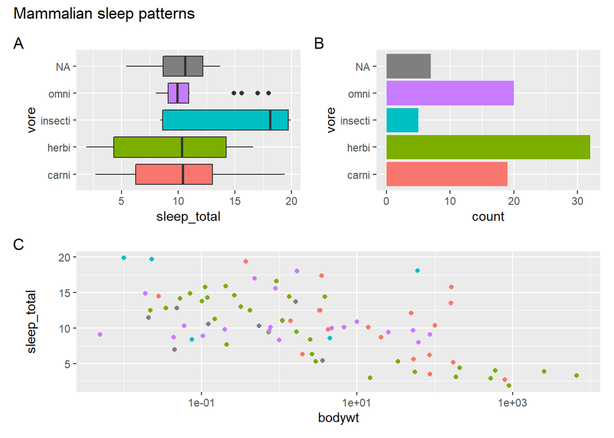

```r
p_all <- p_all & theme(legend.position = 'none')
p_all + plot_annotation(
  title = 'Mammalian sleep patterns',
  tag_levels = 'A'
)
```

### 动画

ggplot2 是静态绘图, gganimate使得在同样的语法框架下实现动态绘图。

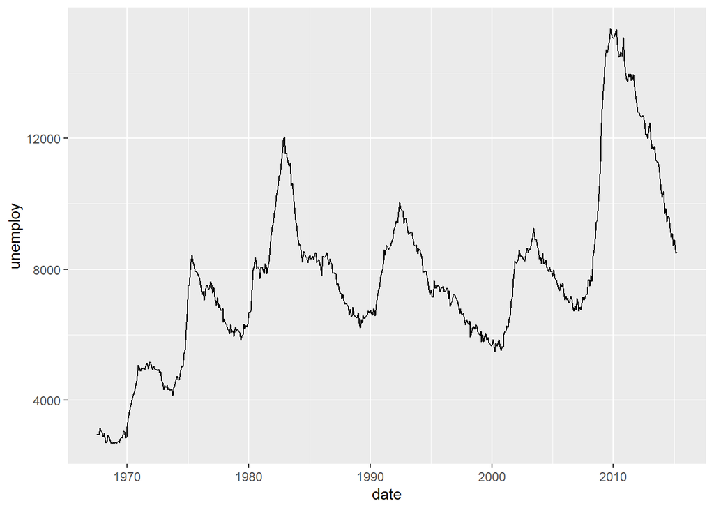

```r
ggplot(economics) +
  geom_line(aes(x = date, y = unemploy))
```

```r
# library(gganimate)
# ggplot(economics) +
#   geom_line(aes(x = date, y = unemploy)) +
#   transition_reveal(along = date)
```

```r
ggplot(mpg) +
  geom_bar(aes(x = factor(cyl)))
ggplot(mpg) +
  geom_bar(aes(x = factor(cyl))) +
  labs(title = 'Number of cars in {closest_state} by number of cylinders') +
  transition_states(states = year) +
  enter_grow() +
  exit_fade()
```

### Annotation

原生的geom_text经常会严重的重叠。

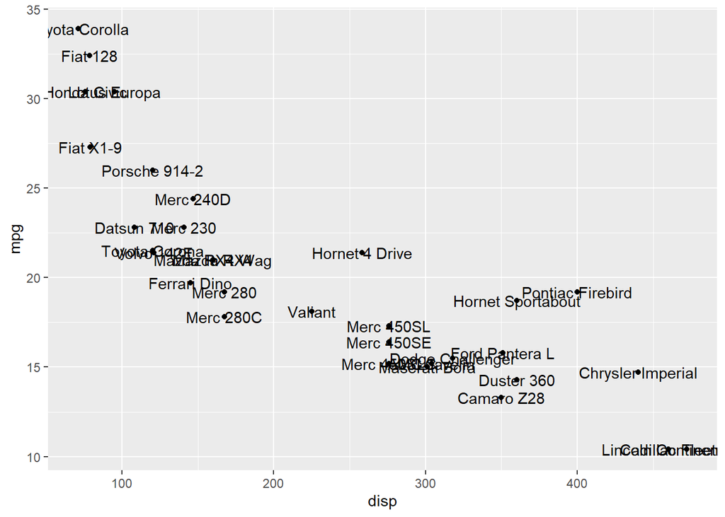

```r
ggplot(mtcars, aes(x = disp, y = mpg)) +
  geom_point() +
  geom_text(aes(label = row.names(mtcars)))
```

ggrepel 可以显著改善此问题，语法没有变化。

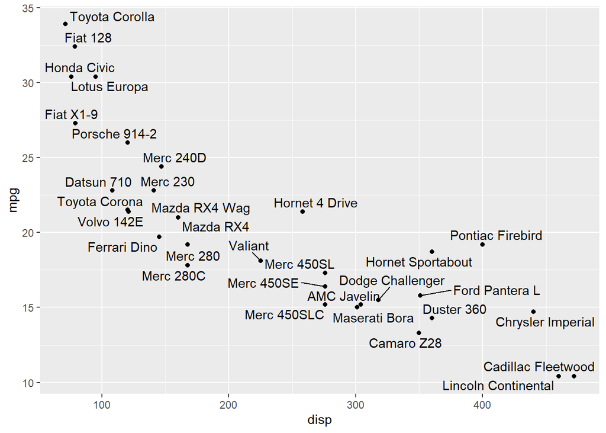

```r
library(ggrepel)
ggplot(mtcars, aes(x = disp, y = mpg)) +
  geom_point() +
  geom_text_repel(aes(label = row.names(mtcars)))
```

可以使用 `geom_mark_*()` 对某部分(根据filter条件) 给与highlight

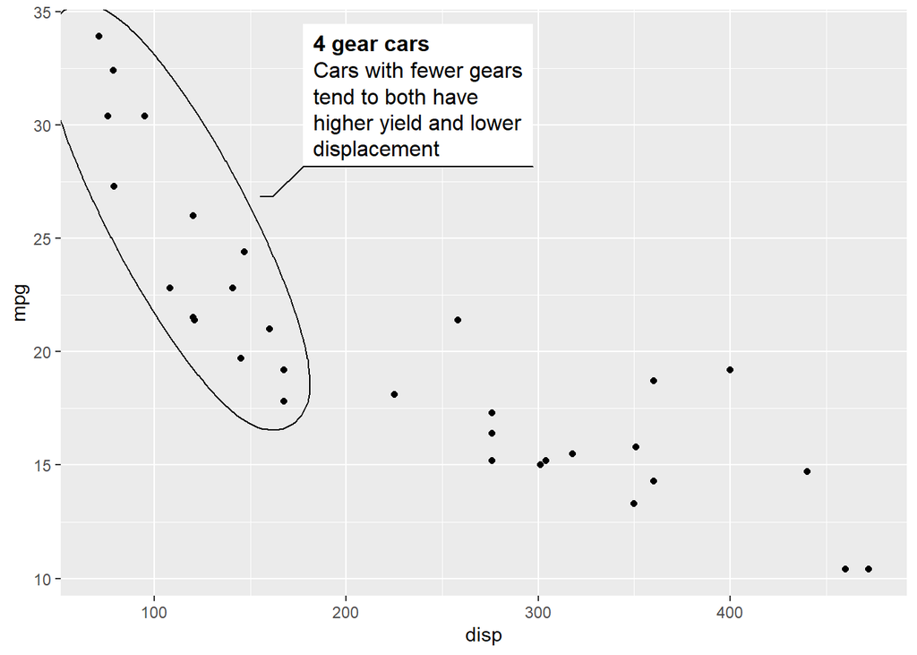

```r
library(ggforce)
ggplot(mtcars, aes(x = disp, y = mpg)) +
  geom_point() +
  geom_mark_ellipse(aes(filter = gear == 4,
                        label = '4 gear cars',
                        description = 'Cars with fewer gears tend to both have higher yield and lower displacement'))
```

### Networks

ggplot2 的绘制数据对象基本都是tabular data，网络数据可视化可以用 ggraph

```
## Using `stress` as default layout
```

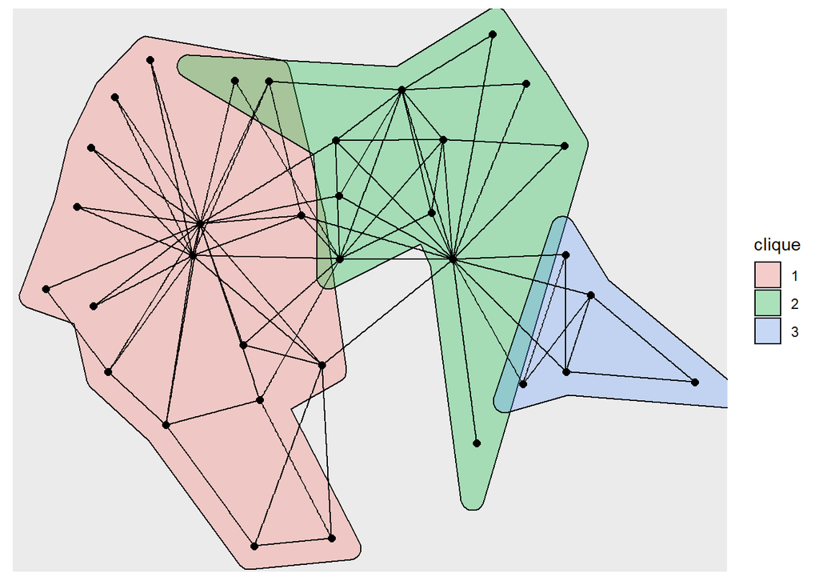

```r
library(ggraph)
library(tidygraph)
graph <- create_notable('zachary') %>%
  mutate(clique = as.factor(group_infomap()))
ggraph(graph) +
  geom_mark_hull(aes(x, y, fill = clique)) +
  geom_edge_link() +
  geom_node_point(size = 2)
```

dendrograms 是一类特殊的网络图

```
## Using `dendrogram` as default layout
```

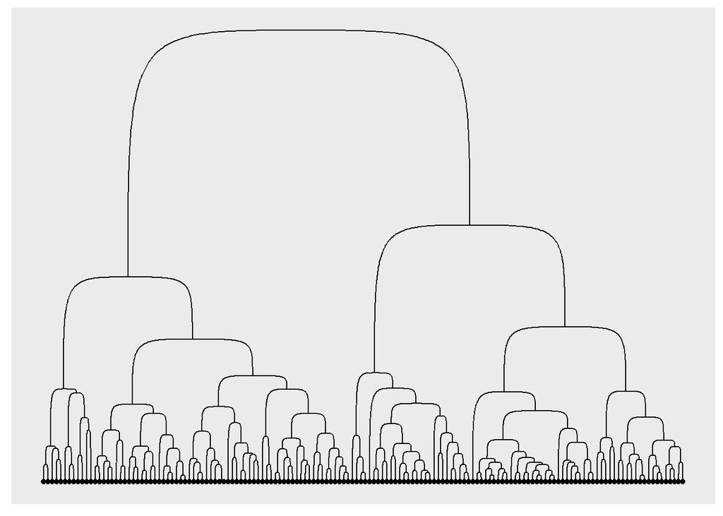

```r
iris_clust <- hclust(dist(iris[, 1:4]))
ggraph(iris_clust) +
  geom_edge_bend() +
  geom_node_point(aes(filter = leaf))
```

### Looks

有很多外观选择，一般以不同的theme设置出现。

[output not shown]

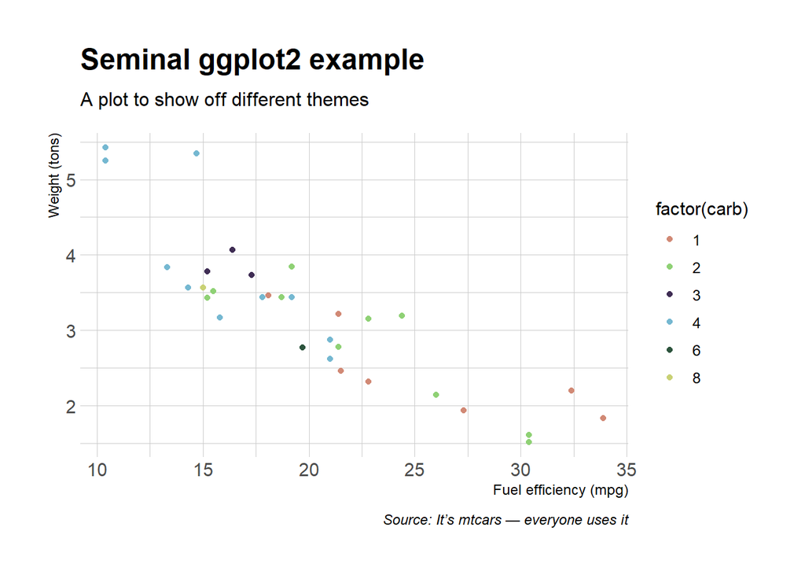

```r
p <- ggplot(mtcars, aes(mpg, wt)) +
  geom_point(aes(color = factor(carb))) +
  labs(
    x = 'Fuel efficiency (mpg)',
    y = 'Weight (tons)',
    title = 'Seminal ggplot2 example',
    subtitle = 'A plot to show off different themes',
    caption = 'Source: It’s mtcars — everyone uses it'
  )
library(hrbrthemes)
p +
  scale_colour_ipsum() +
  theme_ipsum()
```

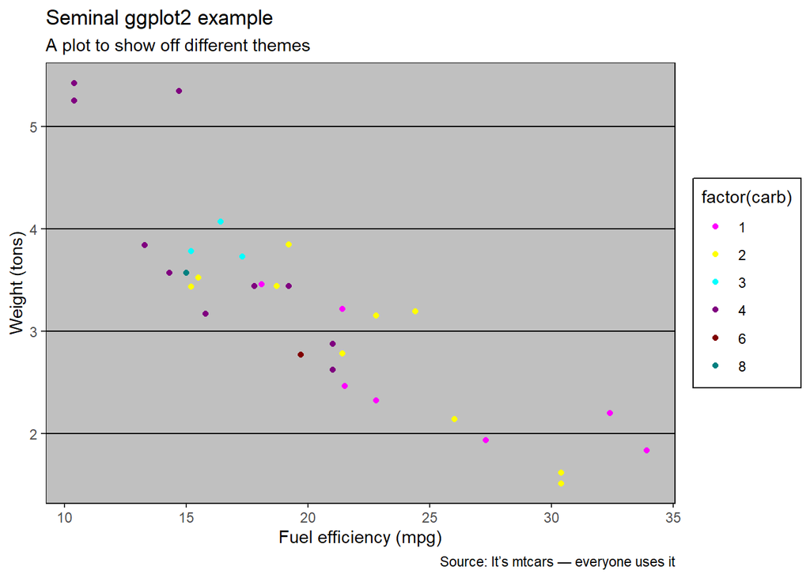

```r
library(ggthemes)
p +
  scale_colour_excel() +
  theme_excel()
```